# Budapest Property Market: Optimization

Benoît Guillaud

19 July 2017

# Abstract

This is the last in a series of three papers aimed to illustrate the use of simple R tools for the analysis of a city’s Real Property market. We previously covered Exploratory Data Analysis (Paper 1) and built predictive models using machine learning algorithms (Paper 2). In this third paper, we use the models of projected rental income and property prices as surrogates in an optimization routine in order to find the best return on investment in the design space.

The optimization provides clear insights to the investor to obtain the best returns: the best locations in the city, whether a lift is important, and whether to opt for a large or small flat.

Along the way, we will demonstrate how to use `mlrMBO::` package, a model-based optimization framework in R.

# Problem definition

Note that each variable has a distinct type: continuous or categorical. They can take any value within the range/list specified.

There are no optimization constraint per se. A constraint would be useful if you had a defined budget not to exceed or a minimum investment target.

# Surrogate models

Let’s create simple models for (1) the annual rental income and (2) the property price. We will use them as surrogate “black-box” models in the optimization routine.

Linear regression models, using 3 features (varos, area, lift):

```r
# train linear regression model
price_mod_lm.A <- stats::lm(price ~ area + varos + lift,
                            data = elado.train,
                            na.action = na.omit)

# model summary
summary(price_mod_lm.A)

# Predictions on testing set
price_pred_lm.A <- predict(price_mod_lm.A, newdata=na.omit(elado.test))

# # evaluate model on testing set
# with(subset(na.omit(elado.test)),
#      EvaluateModel(price, price_pred_lm.A))
```

[output not shown]

```r
# train linear regression model
rent_mod_lm.A <- stats::lm(rent ~ area + varos + lift,
                            data = kiado.train,
                            na.action = na.omit)
# model summary
summary(rent_mod_lm.A)

# Predictions on testing set
rent_pred_lm.A <- predict(rent_mod_lm.A, newdata=na.omit(kiado.test))

# # evaluate model on testing set
# with(subset(na.omit(kiado.test)),
#      EvaluateModel(rent, rent_pred_lm.A))
```

[output not shown]

# Optimization with mlrMBO

The following steps are needed to start the optimization:

- Define the objective function and its parameters using the package smoof.
- Generate an initial design (optional).
- Define a mlr learner for the surrogate model (optional).
- Set up a MBO control object.
- Finally start the optimization with mbo().

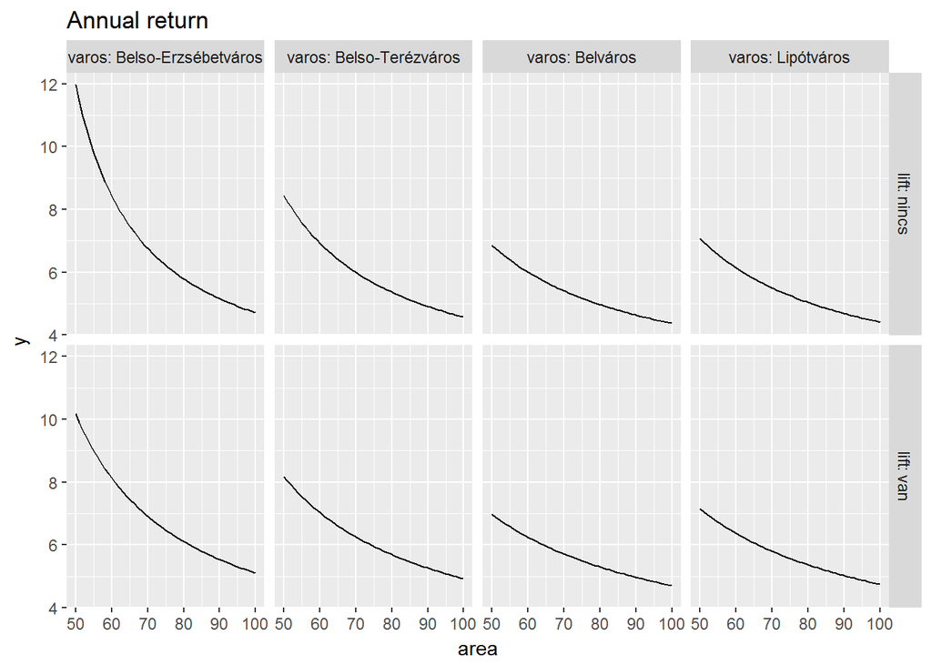

```r
# define objective function
fun = function(x) {
  df <- data.frame(area = x$area,
                     lift = x$lift,
                     varos = x$varos)
  pp <- predict(price_mod_lm.A, newdata=df)
  rr <- predict(rent_mod_lm.A, newdata=df)

  anr = rr/pp * 100
  return(anr)
}

obj.fun = makeSingleObjectiveFunction(
  name = "Annual return",
  fn = fun,
  par.set = makeParamSet(
    makeNumericParam("area", lower = 50, upper = 100),
    makeDiscreteParam("lift", values = c("nincs", "van")),
    makeDiscreteParam("varos", values = c("Belso-Erzsébetváros", "Belso-Terézváros",
                                          "Belváros", "Lipótváros"))
  ),
  has.simple.signature = FALSE,
  minimize = FALSE
)

# visualize the function
autoplot(obj.fun)
```

The objective function plots show at a glance that the best returns are achieved in Belso-Erzsébetváros, for the smaller flat without any lift. The visualization is easy with 3 features. The `mbo()` routine below becomes mandatory when the prediction is based on more variables.

```r
# generate initial design (optional)
des = generateDesign(n = 20, par.set = getParamSet(obj.fun), fun = lhs::randomLHS)

# define mlr learner for surrogate model (optional)
mlr::configureMlr(show.info = FALSE, show.learner.output = FALSE, on.learner.warning = "quiet")
surr.rf = makeLearner("regr.randomForest", predict.type = "se")

# set MBO control object
mbo.ctrl = makeMBOControl()
mbo.ctrl = setMBOControlTermination(mbo.ctrl, iters = 100)
mbo.ctrl = setMBOControlInfill(mbo.ctrl, crit = makeMBOInfillCritEI())

# start optimization with mbo().
run = mbo(obj.fun, control = mbo.ctrl, design = des, learner = surr.rf,  show.info = TRUE)
```

```r
# diagnostic
print(run)
```

```
## Recommended parameters:
## area=50; lift=nincs; varos=Belso-Erzsébetváros
## Objective: y = 11.971
##
## Optimization path
## 20 + 100 entries in total, displaying last 10 (or less):
##         area  lift               varos         y dob eol error.message
## 111 51.27741 nincs Belso-Erzsébetváros 11.313516  91  NA          <NA>
## 112 51.14882 nincs Belso-Erzsébetváros 11.375753  92  NA          <NA>
## 113 51.26315   van Belso-Erzsébetváros  9.833502  93  NA          <NA>
## 114 50.25905 nincs    Belso-Terézváros  8.401519  94  NA          <NA>
## 115 50.04379 nincs          Lipótváros  7.074277  95  NA          <NA>
## 116 81.95309 nincs Belso-Erzsébetváros  5.651681  96  NA          <NA>
## 117 55.81863 nincs Belso-Erzsébetváros  9.549462  97  NA          <NA>
## 118 52.31481 nincs Belso-Erzsébetváros 10.840478  98  NA          <NA>
```

[output cut: 24 more lines]

```r
#plot(run)
```

As expected, the output of the optimization recommends to invest into a small flat, without a lift, in elso-Erzsébetváros.

# Conclusions

The analysis above illustrates the power of the `mlrMBO` framework. Other optimization packages are available in R but I found `mlrMBO` particularly apt at handling the problem at hand:

- Global optimization problem, with potentially multiple maxima and minima
- Non-smooth problem, because of the categorical variables: the objective function does not possess derivatives
- Optimization under (linear or non-linear) constraints
- Handling of “black-box” models - the surrogates

Additional references for optimization in R include:

- mlrMBO, a toolbox for model-based optimization https://cran.r-project.org/web/packages/mlrMBO/index.html
- ROI, a framework for handling optimization problems https://cran.r-project.org/web/packages/ROI/index.html and https://www.r-project.org/conferences/useR-2010/slides/Theussl+Hornik+Meyer.pdf
- Book on optimization with R: https://www.amazon.com/Nonlinear-Parameter-Optimization-Using-Tools/dp/1118569288 (`optimx` package) and http://www3.dsi.uminho.pt/pcortez/mor/ (`tabuSearch` package)
- Other good reads: https://fr.mathworks.com/help/gads/index.html and https://cran.r-project.org/web/views/Optimization.html